# An Alternative to the Correlation Coefficient That Works For Numeric *and* Categorical Variables

[Rama Ramakrishnan](https://mitsloan.mit.edu/faculty/directory/rama-ramakrishnan)

June 6, 2020

### The Problem

When starting to work with a new dataset, it is useful to quickly pinpoint which pairs of variables appear to be *strongly related*. It helps you spot data issues, make better modeling decisions, and ultimately arrive at better answers.

The [*correlation coefficient*](https://en.wikipedia.org/wiki/Correlation_coefficient) is used widely for this purpose but it is well-known that it can’t detect non-linear relationships. Take a look at this scatterplot of two variables $x$ and $y$.

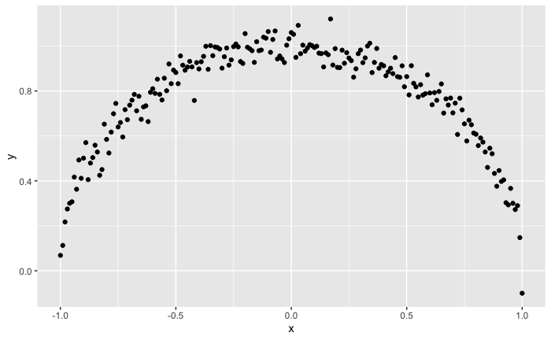

```r
set.seed(42)
x <- seq(-1,1,0.01)
y <- sqrt(1 - x^2) + rnorm(length(x),mean = 0, sd = 0.05)

ggplot(mapping = aes(x, y)) +
  geom_point()
```

It is obvious to the human eye that $x$ and $y$ have a strong relationship but the correlation coefficient between $x$ and $y$ is only -0.01.

Further, if either variable of the pair is *categorical*, we can’t use the correlation coefficient. We will have to turn to other metrics. If $x$ and $y$ are **both** categorical, we can try [Cramer’s V](https://en.wikipedia.org/wiki/Cram%C3%A9r%27s_V) or [the phi coefficient](https://en.wikipedia.org/wiki/Phi_coefficient). If $x$ is continuous and $y$ is binary, we can use the [point-biserial correlation coefficient.](https://en.wikipedia.org/wiki/Point-biserial_correlation_coefficient)

But using different metrics is problematic. Since they are derived from different assumptions, we can’t **compare the resulting numbers with one another**. If the correlation coefficient between continuous variables $x$ and $y$ is 0.6 and the phi coefficient between categorical variables $u$ and $v$ is also 0.6, can we safely conclude that the relationships are equally strong? According to [Wikipedia](https://en.wikipedia.org/wiki/Phi_coefficient),

> The correlation coefficient ranges from −1 to +1, where ±1 indicates perfect agreement or disagreement, and 0 indicates no relationship. The phi coefficient has a maximum value that is determined by the distribution of the two variables if one or both variables can take on more than two values.

A phi coefficient value of 0.6 between $u$ and $v$ may not mean much if its maximum possible value in this particular situation is much higher. Perhaps we can normalize the phi coefficient to map it to the 0-1 range? But what if that modification introduces biases?

Wouldn’t it be nice if we had **one** uniform approach that was easy to understand, worked for continuous **and** categorical variables alike, and could detect linear **and** nonlinear relationships?

(BTW, when $x$ and $y$ are continuous, looking at a scatter plot of $x$ vs $y$ can be very effective since the human brain can detect linear and non-linear patterns very quickly. But even if you are lucky and *all* your variables are continuous, looking at scatterplots of *all* pairs of variables is hard when you have lots of variables in your dataset; with just 100 predictors (say), you will need to look through 4950 scatterplots and this obviously isn’t practical)

### A Potential Solution

To devise a metric that satisfies the requirements we listed above, let’s *invert* the problem: What does it mean to say that $x$ and $y$ **don’t** have a strong relationship?

Intuitively, if there’s no relationship between $x$ and $y$, we would expect to see no patterns in a scatterplot of $x$ and $y$ - no lines, curves, groups etc. It will be a cloud of points that appears to be randomly scattered, perhaps something like this:

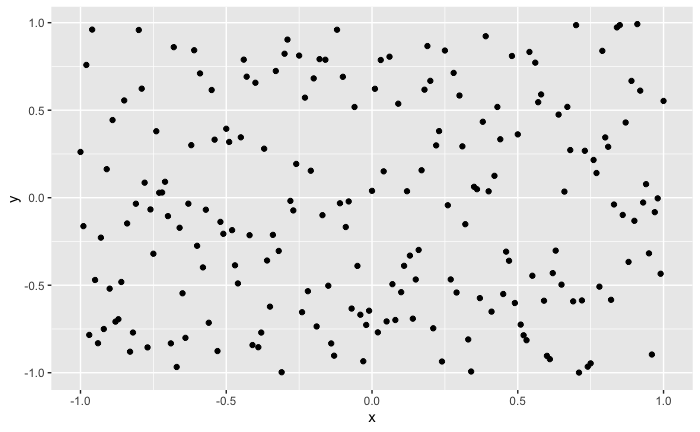

```r
x <- seq(-1,1,0.01)
y <- runif(length(x),min = -1, max = 1)

ggplot(mapping = aes(x, y)) +
  geom_point()
```

In this situation, does knowing the value of $x$ give us any information on $y$?

Clearly not. $y$ seems to be somewhere between -1 and 1 with no particular pattern, regardless of the value of $x$. Knowing $x$ does not seem to help *reduce our uncertainty* about the value of $y$.

In contrast, look at the first picture again.

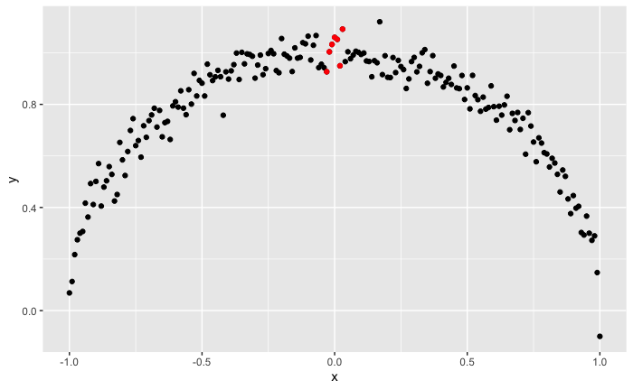

Here, knowing the value of $x$ *does* help. If we know that $x$ is around 0.0, for example, from the graph we will guess that $y$ is likely near 1.0 (the red dots). We can be confident that $y$ is **not** between 0 and 0.8. Knowing $x$ helps us eliminate certain values of $y$, **reducing our uncertainty** about the values $y$ might take.

This notion - that knowing something reduces our uncertainty about something else - is exactly the idea behind [mutual information](https://en.wikipedia.org/wiki/Mutual_information) from [Information Theory](https://en.wikipedia.org/wiki/Information_theory).

According to [Wikipedia](https://en.wikipedia.org/wiki/Mutual_information) (emphasis mine),

> Intuitively, mutual information measures the information that $X$ and $Y$ share: It measures **how much knowing one of these variables reduces uncertainty about the other**. For example, if $X$ and $Y$ are independent, then knowing $X$ does not give any information about $Y$ and vice versa, so their mutual information is zero.

Furthermore,

> **Not limited to real-valued random variables and linear dependence like the correlation coefficient**, MI is more general and determines how different the joint distribution of the pair $(X,Y)$ is to the product of the marginal distributions of $X$ and $Y$.

This is very promising!

As it turns out, however, implementing mutual information is not so simple. We first need to estimate the joint probabilities (i.e., the joint probability density/mass function) of $x$ and $y$ before we can calculate their Mutual Information. If $x$ and $y$ are categorical, this is easy but if one or both of them is continuous, it is more involved.

But we can use the basic insight behind mutual information – that knowing $x$ may reduce our uncertainty about $y$ – in a different way.

### The X2Y Metric

Consider three variables $x$, $y$ and $z$. If knowing $x$ reduces our uncertainty about $y$ by 70% but knowing $z$ reduces our uncertainty about $y$ by only 40%, we will intuitively expect that the association between $x$ and $y$ will be stronger than the association between $z$ and $y$.

So, if we can *quantify* the reduction in uncertainty, that can be used as a measure of the strength of the association. One way to do so is to measure $x$’s ability to *predict* $y$ - after all, **if $x$ reduces our uncertainty about $y$, knowing $x$ should help us predict $y$ better than if we didn’t know $x$**.

Stated another way, we can think of reduction in prediction error $\approx$ reduction in uncertainty $\approx$ strength of association.

This suggests the following approach:

1. Predict $y$ *without using* $x$.
   - If $y$ is continuous, we can simply use the average value of $y$.
   - If $y$ is categorical, we can use the most frequent value of $y$.
   - These are sometimes referred to as a *baseline* model.
2. Predict $y$ *using* $x$
   - We can take any of the standard predictive models out there (Linear/Logistic Regression, CART, Random Forests, SVMs, Neural Networks, Gradient Boosting etc.), set $x$ as the independent variable and $y$ as the dependent variable, fit the model to the data, and make predictions. More on this below.
3. Calculate the **% decrease in prediction error** when we go from (1) to (2)
   - If $y$ is continuous, we can use any of the familiar error metrics like RMSE, SSE, MAE etc. I prefer mean absolute error (MAE) since it is less susceptible to outliers and is in the same units as $y$ but this is a matter of personal preference.
   - If $y$ is categorical, we can use Misclassification Error (= 1 - Accuracy) as the error metric.

> In summary, the % reduction in error when we go from a baseline model to a predictive model measures the strength of the relationship between $x$ and $y$. We will call this metric `x2y` since it measures the ability of $x$ to predict $y$.

(This definition is similar to [*R-Squared*](https://en.wikipedia.org/wiki/Coefficient_of_determination) from Linear Regression. In fact, if $y$ is continuous and we use the Sum of Squared Errors as our error metric, the `x2y` metric is equal to R-Squared.)

To implement (2) above, we need to pick a predictive model to use. Let’s remind ourselves of what the requirements are:

- If there’s a non-linear relationship between $x$ and $y$, the model should be able to detect it
- It should be able to handle all possible $x$-$y$ variable types: continuous-continuous, continuous-categorical, categorical-continuous and categorical-categorical
- We may have hundreds (if not thousands) of pairs of variables we want to analyze so we want this to be quick

[Classification and Regression Trees (CART)](https://en.wikipedia.org/wiki/Decision_tree_learning) satisfies these requirements very nicely and that’s the one I prefer to use. That said, you can certainly use other models if you like.

Let’s try this approach on the ‘semicircle’ dataset from above. We use CART to predict $y$ using $x$ and here’s how the fitted values look:

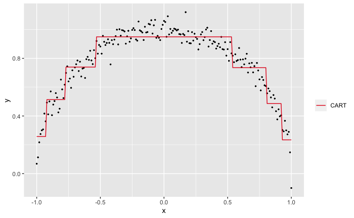

```r
# Let's generate the data again
set.seed(42)
x <- seq(-1,1,0.01)

d <- data.frame(x = x,
                    y = sqrt(1 - x^2) + rnorm(length(x),mean = 0, sd = 0.05))

library(rpart)
preds <- predict(rpart(y~x, data = d, method = "anova"), type = "vector")

# Set up a chart
ggplot(data = d, mapping = aes(x = x)) +
  geom_point(aes(y = y), size = 0.5) +
  geom_line(aes(y=preds, color = '2')) +
  scale_color_brewer(name = "", labels='CART', palette="Set1")
```

Visually, the CART predictions seem to approximate the semi-circular relationship between $x$ and $y$. To confirm, let’s calculate the `x2y` metric step by step.

- The MAE from using the average of $y$ to predict $y$ is 0.19.
- The MAE from using the CART predictions to predict $y$ is 0.06.
- The % reduction in MAE is 68.88%.

Excellent!

If you are familiar with CART models, it is straightforward to implement the `x2y` metric in the Machine Learning environment of your choice. An R implementation is here and details can be found in the appendix but, for now, I want to highlight two functions from the R script that we will use in the examples below:

- `x2y(u, v)` calculates the `x2y` metric between two vectors $u$ and $v$
- `dx2y(d)` calculates the `x2y` metric between all pairs of variables in a dataframe $d$

### Two Caveats

Before we demonstrate the `x2y` metric on a couple of datasets, I want to highlight two aspects of the `x2y` approach.

Unlike metrics like the correlation coefficient, the `x2y` metric is **not** symmetric with respect to $x$ and $y$. The extent to which $x$ can predict $y$ can be different from the extent to which $y$ can predict $x$. For the semi-circle dataset, `x2y(x,y)` is 68.88% but `x2y(y,x)` is only 10.2%.

This shouldn’t come as a surprise, however. Let’s look at the scatterplot again but with the axes reversed.

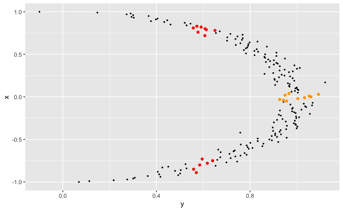

```r
ggplot(data = d, mapping = aes(x = y)) +
  geom_point(aes(y = x), size = 0.5)  +
  geom_point(data = d[abs(d$x) < 0.05,], aes(x = y, y = x), color = "orange" ) +
  geom_point(data = d[abs(d$y-0.6) < 0.05,], aes(x = y, y = x), color = "red" )
```

But there’s an easy solution if you *must* have a symmetric metric for your application: just take the average of `x2y(x,y)` and `x2y(y,x)`.

The second aspect worth highlighting is about the comparability of the `x2y` metric across variable pairs. All `x2y` values where the $y$ variable is continuous will be measuring a % reduction in MAE. All `x2y` values where the $y$ variable is categorical will be measuring a % reduction in Misclassification Error. Is a 30% reduction in MAE equal to a 30% reduction in Misclassification Error? It is problem dependent, there’s no universal right answer.

On the other hand, since (1) *all* `x2y` values are on the same 0-100% scale (2) are conceptually measuring the same thing, i.e., reduction in prediction error and (3) our objective is to quickly scan and identify strongly-related pairs (rather than conduct an in-depth investigation), the `x2y` approach may be adequate.

### Application to the Iris Dataset

The [iris flower dataset](https://en.wikipedia.org/wiki/Iris_flower_data_set) is iconic in the statistics/ML communities and is widely used to illustrate basic concepts. The dataset consists of 150 observations in total and each observation has four continuous variables - the length and the width of petals and sepals - and a categorical variable indicating the species of iris.

Let’s take a look at 10 randomly chosen rows.

```r
iris %>% sample_n(10) %>% pander
```

```
----------------------------------------------------------------------
 Sepal.Length   Sepal.Width   Petal.Length   Petal.Width    Species
-------------- ------------- -------------- ------------- ------------
      6             2.7           5.1            1.6       versicolor

      6             2.2            5             1.5       virginica

      5             3.4           1.5            0.2         setosa

     5.7             3            4.2            1.2       versicolor

     7.4            2.8           6.1            1.9       virginica

     6.5             3            5.8            2.2       virginica

     6.4            2.9           4.3            1.3       versicolor

     6.7            3.1           5.6            2.4       virginica

     7.1             3            5.9            2.1       virginica

     5.1            3.5           1.4            0.3         setosa
----------------------------------------------------------------------
```

We can calculate the `x2y` values for all pairs of variables in `iris` by running `dx2y(iris)` in R (details of how to use the `dx2y()` function are in the appendix).

```r
dx2y(iris) %>% pander
```

```
---------------------------------------------------
      x              y         perc_of_obs    x2y
-------------- -------------- ------------- -------
 Petal.Width      Species          100        94

 Petal.Length     Species          100        93

 Petal.Width    Petal.Length       100       80.73

   Species      Petal.Length       100       79.72

 Petal.Length   Petal.Width        100       77.32

   Species      Petal.Width        100       76.31

 Sepal.Length   Petal.Length       100       66.88

 Sepal.Length     Species          100        62

 Petal.Length   Sepal.Length       100       60.98

 Sepal.Length   Petal.Width        100       54.36

 Petal.Width    Sepal.Length       100       48.81

   Species      Sepal.Length       100       42.08

 Sepal.Width      Species          100        39

 Petal.Width    Sepal.Width        100       31.75

 Petal.Length   Sepal.Width        100        30

 Sepal.Width    Petal.Length       100       28.16

 Sepal.Width    Petal.Width        100       23.02

   Species      Sepal.Width        100       22.37

 Sepal.Length   Sepal.Width        100       18.22

 Sepal.Width    Sepal.Length       100       12.18
---------------------------------------------------
```

The first two columns in the output are self-explanatory. The third column - `perc_of_obs` - is the % of observations in the dataset that was used to calculate that row’s `x2y` value. When a dataset has missing values, only observations that have values present for both $x$ and $y$ will be used to calculate the `x2y` metrics for that variable pair. The `iris` dataset has no missing values so this value is 100% for all rows. The fourth column is the value of the `x2y` metric and the results are sorted in descending order of this value.

Looking at the numbers, both `Petal.Length` and `Petal.Width` seem to be highly associated with `Species` (and with each other). In contrast, it appears that `Sepal.Length` and `Sepal.Width` are very weakly associated with each other.

Note that even though `Species` is categorical and the other four variables are continuous, we could simply “drop” the `iris` dataframe into the `dx2y()` function and calculate the associations between all the variables.

### Application to a COVID-19 Dataset

Next, we examine a [COVID-19 dataset](https://github.com/rama100/x2y/blob/main/covid19.csv) that was downloaded from the [COVID-19 Clinical Data Repository](https://github.com/mdcollab/covidclinicaldata/) in April 2020. This dataset contains clinical characteristics and COVID-19 test outcomes for 352 patients. Since it has a good mix of continuous and categorical variables, having something like the `x2y` metric that can work for any type of variable pair is convenient.

Let’s read in the data and take a quick look at the columns.

```r
df <- read.csv("covid19.csv", stringsAsFactors = FALSE)
str(df) %>% pander
```

```
'data.frame':   352 obs. of  45 variables:
 $ date_published               : chr  "2020-04-14" "2020-04-14" "2020-04-14" "2020-04-14" ...
 $ clinic_state                 : chr  "CA" "CA" "CA" "CA" ...
 $ test_name                    : chr  "Rapid COVID-19 Test" "Rapid COVID-19 Test" "Rapid COVID-19 Test" "Rapid COVID-19 Test" ...
 $ swab_type                    : chr  "" "Nasopharyngeal" "Nasal" "" ...
 $ covid_19_test_results        : chr  "Negative" "Negative" "Negative" "Negative" ...
 $ age                          : int  30 77 49 42 37 23 71 28 55 51 ...
 $ high_risk_exposure_occupation: logi  TRUE NA NA FALSE TRUE FALSE ...
 $ high_risk_interactions       : logi  FALSE NA NA FALSE TRUE TRUE ...
 $ diabetes                     : logi  FALSE FALSE FALSE FALSE FALSE FALSE ...
 $ chd                          : logi  FALSE FALSE FALSE FALSE FALSE FALSE ...
 $ htn                          : logi  FALSE TRUE FALSE TRUE FALSE FALSE ...
 $ cancer                       : logi  FALSE FALSE FALSE FALSE FALSE FALSE ...
 $ asthma                       : logi  TRUE TRUE FALSE TRUE FALSE FALSE ...
 $ copd                         : logi  FALSE FALSE FALSE FALSE FALSE FALSE ...
```

[output cut: 31 more lines]

There are lots of missing values (denoted by ‘NA’) and lots of blanks as well - for example, see the first few values of the `rapid_flu_results` field above. We will convert the blanks to NAs so that all the missing values can be treated consistently. Also, the rightmost three columns are free-text fields so we will remove them from the dataframe.

```r
df <- read.csv("covid19.csv",
                  stringsAsFactors = FALSE,
                  na.strings=c("","NA") # read in blanks as NAs
                  )%>%
  select(-starts_with("cxr"))  # remove the chest x-ray note fields

str(df) %>% pander
```

```
'data.frame':   352 obs. of  42 variables:
 $ date_published               : chr  "2020-04-14" "2020-04-14" "2020-04-14" "2020-04-14" ...
 $ clinic_state                 : chr  "CA" "CA" "CA" "CA" ...
 $ test_name                    : chr  "Rapid COVID-19 Test" "Rapid COVID-19 Test" "Rapid COVID-19 Test" "Rapid COVID-19 Test" ...
 $ swab_type                    : chr  NA "Nasopharyngeal" "Nasal" NA ...
 $ covid_19_test_results        : chr  "Negative" "Negative" "Negative" "Negative" ...
 $ age                          : int  30 77 49 42 37 23 71 28 55 51 ...
 $ high_risk_exposure_occupation: logi  TRUE NA NA FALSE TRUE FALSE ...
 $ high_risk_interactions       : logi  FALSE NA NA FALSE TRUE TRUE ...
 $ diabetes                     : logi  FALSE FALSE FALSE FALSE FALSE FALSE ...
 $ chd                          : logi  FALSE FALSE FALSE FALSE FALSE FALSE ...
 $ htn                          : logi  FALSE TRUE FALSE TRUE FALSE FALSE ...
 $ cancer                       : logi  FALSE FALSE FALSE FALSE FALSE FALSE ...
 $ asthma                       : logi  TRUE TRUE FALSE TRUE FALSE FALSE ...
 $ copd                         : logi  FALSE FALSE FALSE FALSE FALSE FALSE ...
```

[output cut: 28 more lines]

Now, let’s run it through the `x2y` approach. We are particularly interested in non-zero associations between the `covid_19_test_results` field and the other fields so we zero in on those by running `dx2y(df, target = "covid_19_test_results")` in R (details in the appendix) and filtering out the zero associations.

```r
dx2y(df, target = "covid_19_test_results") %>%
  filter(x2y >0) %>%
  pander
```

```
-------------------------------------------------------------
           x                   y         perc_of_obs    x2y
----------------------- --------------- ------------- -------
 covid_19_test_results   loss_of_smell      21.88      18.18

 covid_19_test_results   loss_of_taste      22.73      12.5

 covid_19_test_results       sats           92.9       2.24
-------------------------------------------------------------
```

Only *three* of the 41 variables have a non-zero association with `covid_19_test_results`. Disappointingly, the highest `x2y` value is an unimpressive 18%. It is based on just 22% of the observations (since the other 78% of observations had missing values) and makes one wonder if this modest association is real or if it is just due to chance.

If we were working with the correlation coefficient, we could easily calculate a *confidence interval* for it and gauge if what we are seeing is real or not. Can we do the same thing for the `x2y` metric?

We can, by using bootstrapping. Given $x$ and $y$, we can sample with replacement a 1000 times (say) and calculate the `x2y` metric each time. With these 1000 numbers, we can construct a confidence interval easily (this is available as an optional `confidence` argument in the R functions we have been using; please see the appendix).

Let’s re-do the earlier calculation with “confidence intervals” turned on by running `dx2y(df, target = "covid_19_test_results", confidence = TRUE)` in R.

```r
dx2y(df, target = "covid_19_test_results", confidence = TRUE) %>%
  filter(x2y >0) %>%
  pander(split.tables = Inf)
```

```
-----------------------------------------------------------------------------------------
           x                   y         perc_of_obs    x2y    CI_95_Lower   CI_95_Upper
----------------------- --------------- ------------- ------- ------------- -------------
 covid_19_test_results   loss_of_smell      21.88      18.18      -7.65         36.36

 covid_19_test_results   loss_of_taste      22.73      12.5      -11.01          25

 covid_19_test_results       sats           92.9       2.24       -1.96         4.48
-----------------------------------------------------------------------------------------
```

*The 95% confidence intervals all contain 0.0*, so none of these associations appear to be real.

Let’s see what the top 10 associations are, between *any* pair of variables.

```r
dx2y(df) %>%head(10) %>% pander
```

```
-----------------------------------------------------
       x               y         perc_of_obs    x2y
--------------- --------------- ------------- -------
 loss_of_smell   loss_of_taste      20.17       100

 loss_of_taste   loss_of_smell      20.17       100

    fatigue        headache         40.06      90.91

   headache         fatigue         40.06      90.91

    fatigue       sore_throat       27.84      89.58

   headache       sore_throat       30.4       89.36

  sore_throat       fatigue         27.84      88.89

  sore_throat      headache         30.4       88.64

  runny_nose        fatigue         25.57      84.44

  runny_nose       headache         25.57      84.09
-----------------------------------------------------
```

Interesting. `loss_of_smell` and `loss_of_taste` are *perfectly* associated with each other. Let’s look at the raw data.

```r
with(df, table(loss_of_smell, loss_of_taste))
```

```
             loss_of_taste
loss_of_smell FALSE TRUE
        FALSE    55    0
        TRUE      0   16
```

They agree for *every* observation in the dataset and, as a result, their `x2y` is 100%.

Moving down the `x2y` ranking, we see a number of variables - `fatigue`, `headache`, `sore_throat`, and `runny_nose` - that are *all strongly associated with each other*, as if they are all connected by a common cause.

When the number of variable combinations is high and there are lots of missing values, it can be helpful to scatterplot `x2y` vs `perc_of_obs`.

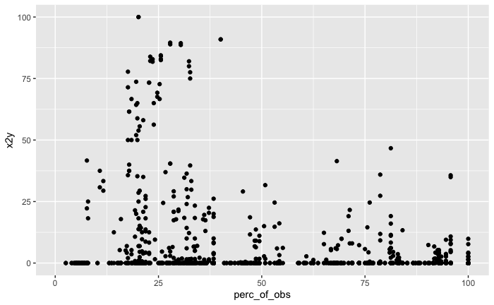

```r
ggplot(data = dx2y(df), aes(y=x2y, x = perc_of_obs)) +
         geom_point()
```

Unfortunately, the top-right quadrant is empty: there are no strongly-related variable pairs that are based on at least 50% of the observations. There *are* some variable pairs with `x2y` values > 75% but none of them are based on more than 40% of the observations.

### Conclusion

Using an insight from Information Theory, we devised a new metric - the `x2y` metric - that quantifies the strength of the association between pairs of variables.

The `x2y` metric has several advantages:

- It works for all types of variable pairs (continuous-continuous, continuous-categorical, categorical-continuous and categorical-categorical)
- It captures linear and non-linear relationships
- Perhaps best of all, it is easy to understand and use.

I hope you give it a try in your work.

### Acknowledgements

Thanks to [Amr Farahat](https://mitsloan.mit.edu/faculty/directory/amr-farahat) for helpful feedback on an earlier draft.

### Appendix: How to use the R script

The [R script](https://github.com/rama100/x2y/blob/main/x2y.R) depends on two R packages - `rpart` and `dplyr` - so please ensure that they are installed in your environment.

The script has two key functions: `x2y()` and `dx2y()`.

#### Using the `x2y()` function

*Usage*: `x2y(u, v, confidence = FALSE)`

*Arguments*:

- `u`, `v`: two vectors of equal length
- `confidence`: (OPTIONAL) a boolean that indicates if a confidence interval is needed. Default is FALSE.

*Value*: A list with the following elements:

- `perc_of_obs`: the % of total observations that were used to calculate `x2y`. If some observations are missing for either $u$ or $v$, this will be less than 100%.
- `x2y`: the `x2y` metric for using $u$ to predict $v$

Additionally, if `x2y()` was called with `confidence = TRUE`:

- `CI_95_Lower`: the lower end of a 95% confidence interval for the `x2y` metric estimated by bootstrapping 1000 samples
- `CI_95_Upper`: the upper end of a 95% confidence interval for the `x2y` metric estimated by bootstrapping 1000 samples

#### Using the `dx2y()` function

*Usage*: `dx2y(d, target = NA, confidence = FALSE)`

*Arguments*:

- `d`: a dataframe
- `target`: (OPTIONAL) if you are only interested in the `x2y` values between a *particular variable* in `d` and all other variables, set `target` equal to the name of the variable you are interested in. Default is NA.
- `confidence`: (OPTIONAL) a boolean that indicates if a confidence interval is needed. Default is FALSE.

*Value*: A dataframe with each row containing the output of running `x2y(u, v, confidence)` for `u` and `v` chosen from the dataframe. Snce this is just a standard R dataframe, it can be sliced, sorted, filtered, plotted etc.